# Can we predict one’s biological age?

Introduction to Linear Modelling

Joao Malato

Nuno Sepulveda

September 16th, 2022

# Libraries

```r
library(here)       # easy directory management, as here("YOUR/FILE/PATH")
library(data.table) # fast data wrangling
library(magrittr)   # use of pipe operator `%>%`
library(ggplot2)    # graphics
library(nortest)    # normality assessment test
```

# Load data

We will be analysing a subset of the whole blood data from 656 human individuals, made available by [Hannun et al. (2013)](https://www.sciencedirect.com/science/article/pii/S1097276512008933?via%3Dihub).

```r
# base R
mdna <- read.csv(here("data/methDNA_data_Hannun_etal_2013.csv"), header = TRUE)

# alternative: using data.table's fread()
# mdna <- fread(here("data/methDNA_data_Hannun_etal_2013.csv"), header = TRUE)
```

```r
# look at first 8 cols from the data
head(mdna[, 1:8])
```

```
##      GEO.ID Age Gender Ethnicity cg17568996 cg02245378 cg14093936 cg15642326
## 1 GSM989827  67      F Caucasian 0.08144546 0.08951550  0.3297176  0.2666367
## 2 GSM989828  89      F Caucasian 0.06307138 0.09956124  0.2693837  0.2525504
## 3 GSM989829  66      F Caucasian 0.12086410 0.10301870  0.3216346  0.2430219
## 4 GSM989830  64      F Caucasian 0.09724835 0.08985170  0.3458824  0.2730094
## 5 GSM989831  62      F Caucasian 0.12239770 0.09564840  0.3497202  0.2836436
## 6 GSM989832  87      F Caucasian 0.19961670 0.16343000  0.3575867  0.2096256
```

Variables:

- `GEO.ID`: Unique identifier for each one of the 656 participants
- `Age`: Age of participants, in years
- `Gender`: Gender of each individual, binary values for female (`F`) and male (`M`)
- `Ethnicity`: Ethnic group of each individual, binary identifying European participants (`Caucasian`) and Mexican participants (`Hispanic`)
- `cgXXXXXXXX`: CpG marker, each one indicating the methylation values, in percentage

```r
# get a vector with all column names with their pattern starting with "cg" (i.e., the names of all CpG probes)
vec_probe <- grep("^cg", colnames(mdna), value = TRUE)
```

# Quick EDA

Things to look for:

1. Look at the population-related variables
   - Are there sampling differences between gender and/or ethnicity?
2. Look at age distribution
   - Does age change with gender/ethnicity?
3. Look at methylation levels
   - Should we transform the data?
   - Are the values correlated with age?
   - Could these values by affected by gender/ethnicity?

## Demographics and age

```r
# Look through the group categories
table(mdna$Gender)
```

```
##
##   F   M
## 338 318
```

```r
table(mdna$Ethnicity)
```

```
##
## Caucasian  Hispanic
##       426       230
```

```r
# gender and ethnicity
table(mdna$Ethnicity, mdna$Gender)
```

```
##
##               F   M
##   Caucasian 222 204
##   Hispanic  116 114
```

```r
# proportions
round(prop.table(table(mdna$Ethnicity, mdna$Gender), margin = 2), 2)
```

```
##
##                F    M
##   Caucasian 0.66 0.64
##   Hispanic  0.34 0.36
```

```r
round(prop.table(table(mdna$Ethnicity, mdna$Gender), margin = 1), 2)
```

```
##
##                F    M
##   Caucasian 0.52 0.48
##   Hispanic  0.50 0.50
```

```r
# Pearson's Chi-squared test
chisq.test(table(mdna$Gender, mdna$Ethnicity))
```

```
##
##  Pearson's Chi-squared test with Yates' continuity correction
##
## data:  table(mdna$Gender, mdna$Ethnicity)
## X-squared = 0.10788, df = 1, p-value = 0.7426
```

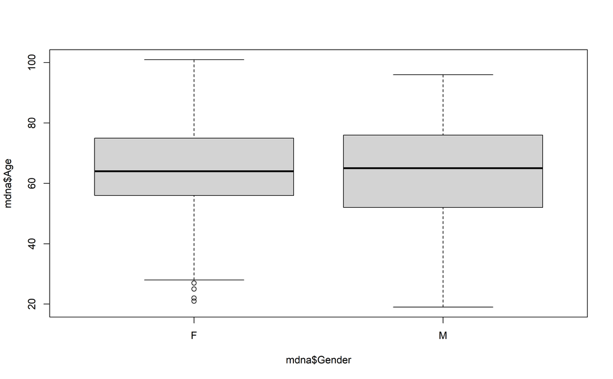

```r
# Gender and Age
boxplot(mdna$Age ~ mdna$Gender)
```

```r
quantile(subset(mdna, Gender == "F")$Age)
```

```
##   0%  25%  50%  75% 100%
##   21   56   64   75  101
```

```r
quantile(subset(mdna, Gender == "M")$Age)
```

```
##    0%   25%   50%   75%  100%
## 19.00 52.00 65.00 75.75 96.00
```

```r
# Mann-Whitney U test
wilcox.test(mdna$Age ~ mdna$Gender)
```

```
##
##  Wilcoxon rank sum test with continuity correction
##
## data:  mdna$Age by mdna$Gender
## W = 55605, p-value = 0.4425
## alternative hypothesis: true location shift is not equal to 0
```

```r
# ggplot2 alternatives

# boxplot:
# ggplot(mdna, aes(x = Gender, y = Age)) +
#   geom_boxplot()

# density plot:
# ggplot(mdna, aes(Age, fill = Gender)) +
#   geom_density(alpha = 0.5)
```

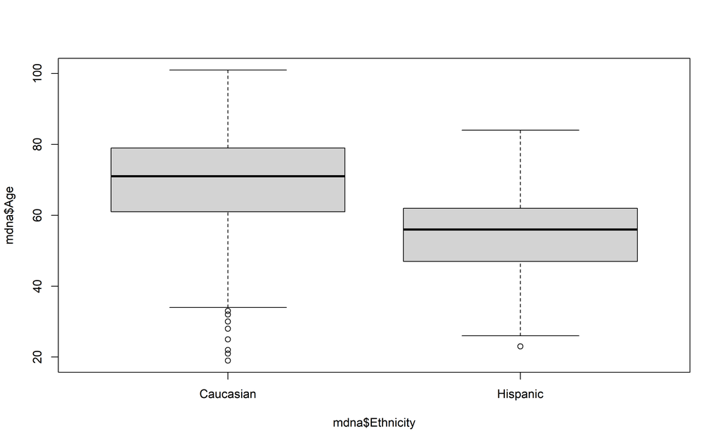

```r
# Ethnicity and Age
boxplot(mdna$Age ~ mdna$Ethnicity)
```

```r
quantile(subset(mdna, Ethnicity == "Caucasian")$Age)
```

```
##   0%  25%  50%  75% 100%
##   19   61   71   79  101
```

```r
quantile(subset(mdna, Ethnicity == "Hispanic")$Age)
```

```
##   0%  25%  50%  75% 100%
##   23   47   56   62   84
```

```r
# Mann-Whitney U test
wilcox.test(mdna$Age ~ mdna$Ethnicity)
```

```
##
##  Wilcoxon rank sum test with continuity correction
##
## data:  mdna$Age by mdna$Ethnicity
## W = 79004, p-value < 2.2e-16
## alternative hypothesis: true location shift is not equal to 0
```

```r
# ggplot2 alternatives

# boxplot:
# ggplot(mdna, aes(x = Ethnicity, y = Age)) +
#   geom_boxplot()

# density plot:
# ggplot(mdna, aes(Age, fill = Ethnicity)) +
#   geom_density(alpha = 0.5)
```

## DNA methylation values

```r
# base summary
summary(mdna[, vec_probe])
```

```
##    cg17568996        cg02245378        cg14093936       cg15642326
##  Min.   :0.03878   Min.   :0.06202   Min.   :0.2360   Min.   :0.1110
##  1st Qu.:0.09808   1st Qu.:0.09436   1st Qu.:0.3190   1st Qu.:0.2419
##  Median :0.12126   Median :0.10358   Median :0.3444   Median :0.2601
##  Mean   :0.12249   Mean   :0.10704   Mean   :0.3436   Mean   :0.2596
##  3rd Qu.:0.14284   3rd Qu.:0.11700   3rd Qu.:0.3682   3rd Qu.:0.2795
##  Max.   :0.27857   Max.   :0.26465   Max.   :0.5108   Max.   :0.4882
##    cg24991452        cg04581377         cg01820374       cg06898923
##  Min.   :0.01363   Min.   :0.002807   Min.   :0.1625   Min.   :0.02812
##  1st Qu.:0.03247   1st Qu.:0.039772   1st Qu.:0.2537   1st Qu.:0.05137
##  Median :0.04142   Median :0.044587   Median :0.2796   Median :0.05834
##  Mean   :0.04235   Mean   :0.044973   Mean   :0.2794   Mean   :0.05933
##  3rd Qu.:0.05175   3rd Qu.:0.050517   3rd Qu.:0.3049   3rd Qu.:0.06635
##  Max.   :0.07500   Max.   :0.090808   Max.   :0.4095   Max.   :0.18484
##    cg11579069        cg19560758       cg17385448       cg03271907
##  Min.   :0.03447   Min.   :0.1396   Min.   :0.1857   Min.   :0.8770
##  1st Qu.:0.06001   1st Qu.:0.2275   1st Qu.:0.3527   1st Qu.:0.9215
##  Median :0.06579   Median :0.2463   Median :0.3789   Median :0.9335
##  Mean   :0.06688   Mean   :0.2487   Mean   :0.3823   Mean   :0.9329
##  3rd Qu.:0.07175   3rd Qu.:0.2685   3rd Qu.:0.4128   3rd Qu.:0.9447
##  Max.   :0.10725   Max.   :0.4399   Max.   :0.5631   Max.   :0.9933
##    cg04081402       cg26614073       cg17895149       cg22736354
##  Min.   :0.7150   Min.   :0.2468   Min.   :0.1666   Min.   :0.1483
##  1st Qu.:0.8334   1st Qu.:0.4023   1st Qu.:0.4865   1st Qu.:0.2878
##  Median :0.8524   Median :0.4361   Median :0.5050   Median :0.3140
##  Mean   :0.8504   Mean   :0.4337   Mean   :0.5043   Mean   :0.3130
##  3rd Qu.:0.8705   3rd Qu.:0.4669   3rd Qu.:0.5247   3rd Qu.:0.3381
##  Max.   :0.9591   Max.   :0.6279   Max.   :0.7508   Max.   :0.5102
##    cg07549715       cg17592812        cg18463417       cg26832211
##  Min.   :0.2752   Min.   :0.01744   Min.   :0.7925   Min.   :0.7379
##  1st Qu.:0.4750   1st Qu.:0.04622   1st Qu.:0.8500   1st Qu.:0.8199
##  Median :0.4998   Median :0.05143   Median :0.8593   Median :0.8430
##  Mean   :0.5007   Mean   :0.05201   Mean   :0.8607   Mean   :0.8412
##  3rd Qu.:0.5273   3rd Qu.:0.05754   3rd Qu.:0.8698   3rd Qu.:0.8637
##  Max.   :0.6470   Max.   :0.13834   Max.   :0.9602   Max.   :0.9574
##    cg05724065       cg11091262       cg09809672       cg11191337
##  Min.   :0.4425   Min.   :0.5998   Min.   :0.2097   Min.   :0.5813
##  1st Qu.:0.6296   1st Qu.:0.7612   1st Qu.:0.3798   1st Qu.:0.7602
##  Median :0.6631   Median :0.7889   Median :0.4350   Median :0.7813
##  Mean   :0.6579   Mean   :0.7869   Mean   :0.4327   Mean   :0.7790
```

[output cut: 36 more lines]

```
##  Max.   :0.19319   Max.   :0.3888   Max.   :0.6083   Max.   :0.29011
##    cg02797569       cg03996822       cg18267374       cg15037004
##  Min.   :0.6644   Min.   :0.2506   Min.   :0.0803   Min.   :0.3129
##  1st Qu.:0.7553   1st Qu.:0.4115   1st Qu.:0.1309   1st Qu.:0.5019
##  Median :0.7750   Median :0.4619   Median :0.1482   Median :0.5397
##  Mean   :0.7732   Mean   :0.4596   Mean   :0.1508   Mean   :0.5397
##  3rd Qu.:0.7932   3rd Qu.:0.5063   3rd Qu.:0.1666   3rd Qu.:0.5836
##  Max.   :0.8856   Max.   :0.7201   Max.   :0.3073   Max.   :0.7122
##    cg01511567        cg09817114
##  Min.   :0.08287   Min.   :0.02313
##  1st Qu.:0.16611   1st Qu.:0.05332
##  Median :0.19103   Median :0.05807
##  Mean   :0.19003   Mean   :0.05881
##  3rd Qu.:0.21399   3rd Qu.:0.06360
##  Max.   :0.29753   Max.   :0.09274
```

```r
# limits of all CpG values
range(apply(mdna[, vec_probe], 2, min),
      apply(mdna[, vec_probe], 2, max))
```

```
## [1] 0.002807284 0.993269100
```

```r
# try:

# plot(apply(mdna[, vec_probe], 2, min), ylim = c(0, 1), pch = 16, col = 2, type = "l")
# lines(apply(mdna[, vec_probe], 2, max), pch = 16, col = 3)
```

The values are given as methylated percentage.

**Question:** Why should we transform the CpG values?

```r
# function for the log-odds transformation
logodds_trans <- function(p) log(p / (1 - p))
```

```r
# transform the percentage values into log-odds
probe_logodds <- apply(mdna[, vec_probe], 2, logodds_trans)

# create data frame to work with
mdna_logodds <- data.frame(mdna[, 1:4], probe_logodds)
```

Henceforth we will be using the `mdna_logodds` data.

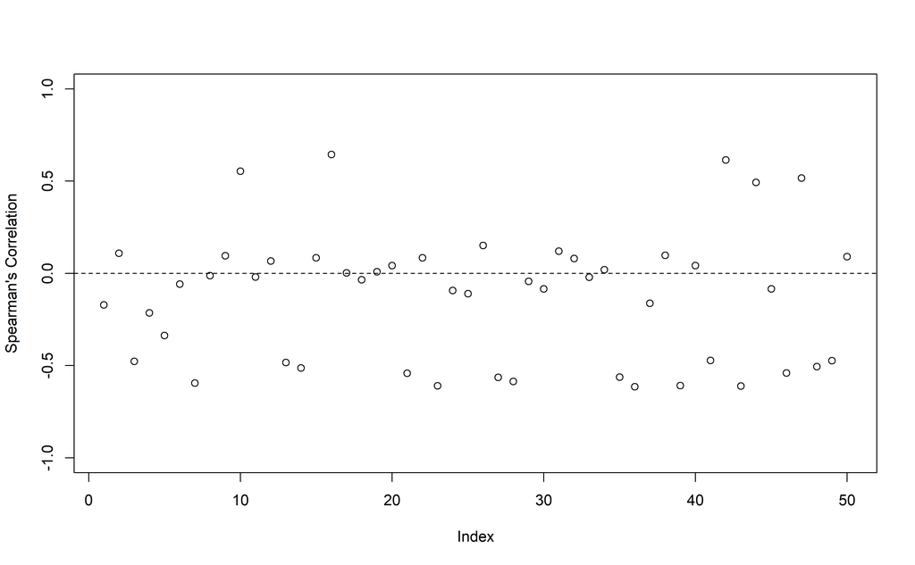

```r
# CpG probes correlation with Age
vec_cor_values <- sapply(seq(vec_probe), function(x) cor(mdna_logodds$Age, mdna_logodds[, vec_probe[x]], method = "spearman"))

# look at the correlation values between each probe and Age
plot(vec_cor_values, ylim = c(-1, 1), ylab = "Spearman's Correlation")
abline(h = 0, lty = 2)
```

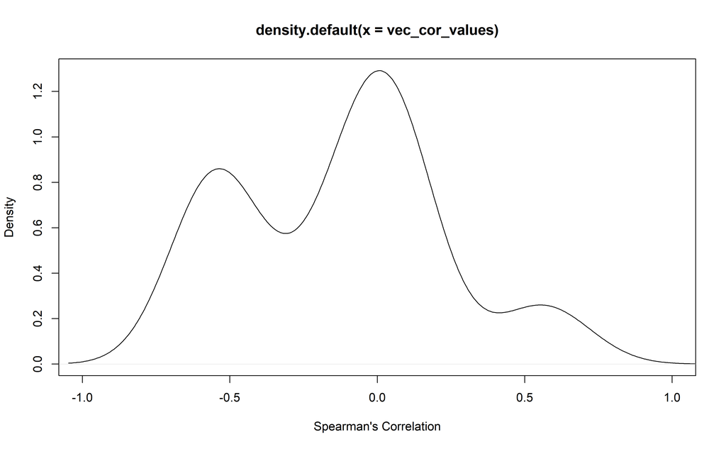

```r
# density plot
plot(density(vec_cor_values), xlab = "Spearman's Correlation", xlim = c(-1, 1))
```

```r
# save the CpG probes ordered by their absolute correlation value
vec_probe_cor <- vec_probe[order(abs(vec_cor_values), decreasing = TRUE)]
```

**Question:** What does having a high positive/negative correlation might indicate?

# Questions

1. Main question: Can we predict one’s biological age?
2. Can we predict the age of an individual based on the methylation level of a given CpG probe?
3. Does gender pose an effect in this prediction?
4. Does ethnicity pose an effect in this prediction?

# **Exercise 1:** Simple linear regression

For this exercise, we will study the relation between age and methylation levels from specific probes.

- Perform a simple linear regression to study the (linear) relationship between Age and a single specific marker (hint: use the function `lm()`)
- For each case, what is the model’s formula (hint: `coef()` or `coefficients()`)
- Model diagnosis
  - Look at the residuals (hint: `resid()` or `residuals()`)
  - Assess their normality (hint: `shapiro.test()`)
- Interpret the results
  - What are the models’ slopes?
  - What are the model predictions?
  - What are the predicted ages of someone with, for any inferred marker, methylation levels of 10%, 25%, 50%, 75%, and 90%? (hint: `predict()` with the *newdata* argument)

## First probe

Linear model using the first CpG probe, cg17568996.

```r
# CpG: cg17568996


# linear regression: formula as Y ~ x
# fit1 <- lm(___, data = mdna_logodds)


# look at the models' summary
# summary(___)
```

**Questions:**

1. How do you interpret the *Estimate* values?
2. Which hypotheses tests are the p-values shown here referring to? What can we infer from the results?
3. What is the difference between the *Multiple R-squared* and *Adjusted R-squared*?

We can look at the model’s residuals distribution. Ideally, the distribution should be symmetric around zero (Normal distribution with $\mu = 0$). We can assess this visually, through the use of a density plot, histogram, violin plot, boxplot, or even a quantile-quantile plot (Q-Q plot).

```r
# residual analysis
# ___


# density plot
# plot(density(___))


# Q-Q plot
# qqnorm(___)
# qqline(___)
```

Alternatively, we can apply formal hypothesis testing to infer on the residuals’ normality.

```r
# proposal 1: Shapiro-Wilk normality test
# ___


# proposal 2: Lilliefors (Kolmogorov-Smirnov) normality test
# nortest::lillie.test(___)
```

Assuming this linear relation between age and the cg17568996 methylation values, what are the model fitted values (i.e., the prediction of the mean response value to the coefficient values used to formulate the model)?

```r
# pred_fit1 <- ___


# look at the fitted results
# ___
```

What are the predicted ages of someone with cg17568996 methylation levels of 10%, 25%, 50%, 75%, and 90%?

```r
# vector with percentages of interest
methylation_interest <- c(0.1, 0.25, 0.5, 0.75, 0.9)
# don't forget to transform the data!


# predictions_fit1 <- ___
```

## Top probe correlated with age

Perform the same analysis with the highest age-correlated probe, cg22736354.

```r
# CpG probe: cg22736354

# linear regression
# fit2 <- ___


# summary
# ___
```

```r
# residuals analysis
# ___
```

```r
# pred_fit2 <- ___


# fitted results
# ___
```

```r
# predictions_fit2 <- ___
```

## Comparing results

From the results of the two linear models what do you see?

- Differences in the summary, R-squared, or coefficients?
- How about the residuals?

```r
# try:

# par(mfrow = c(1, 2))
# plot(mdna_logodds$Age, predict(fit1), xlim = c(0, 100), ylim = c(0, 100), xlab = "Age, years", ylab = "Fitted age, fit1")
# abline(lm(predict(fit1) ~ mdna_logodds$Age))
# abline(0,1, lty = 2, col = "gray55")
# plot(mdna_logodds$Age, predict(fit2), xlim = c(0, 100), ylim = c(0, 100), xlab = "Age, years", ylab = "Fitted age, fit2")
# abline(lm(predict(fit2) ~ mdna_logodds$Age))
# abline(0,1, lty = 2, col = "gray55")
# par(mfrow = c(1, 1))
```

# **Exercise 2:** Multiple linear regression

For this exercise, we will perform the same analysis for the cg22736354 probe, only this time the variables for gender and ethnicity will be included in the model.

- Perform a multiple linear regression
- Model diagnosis
- Compare against the previous model

## **2.1** Adding the coefficient for gender

```r
# CpG: cg22736354


# define gender as a factor with "female" as reference
mdna_logodds$Gender <- relevel(factor(mdna_logodds$Gender), ref = "F")


# fit the model
# fit2_g <- ___


# summary
# ___
```

```r
# assessing normality of residuals
# ___
```

```r
# predictions for age in each gender
# pred_g_female <- ___
# pred_g_male <- ___
```

## **2.2** Adding the coefficient for ethnicity

```r
# CpG: cg22736354


# define gender as a factor with the caucasian group as reference level
mdna_logodds$Ethnicity <- relevel(factor(mdna_logodds$Ethnicity), ref = "Caucasian")


# fit the model
# fit2_e <- ___


# summary
# ___
```

```r
# assessing normality of residuals
# ___
```

```r
# predictions for age in europeans and mexicans
# pred_e_cauc <- ___
# pred_e_hisp <- ___
```

```r
# try:

# plot(mdna_logodds$Age, predict(fit2_e), xlim = c(0, 100), ylim = c(0, 100), col = mdna_logodds$Ethnicity, pch = 16)
# abline(lm(predict(fit2_e) ~ mdna_logodds$Age))
# abline(0,1, lty = 2)

# plot(mdna_logodds$Age, predict(fit2_e), xlim = c(0, 100), ylim = c(0, 100), col = mdna_logodds$Ethnicity, pch = 16)
# abline(0,1, lty = 2)
# abline(lm(pred_e_cauc ~ mdna_logodds$Age), lwd = 3, col = 1)
# abline(lm(pred_e_hisp ~ mdna_logodds$Age), lwd = 3, col = 2)
```

## **2.3** Interaction Interaction `cg22736354:Ethnicity`

- Try to add an interaction term between the two covariates used in the model
- Estimate the values for $\beta_0$ and $\beta_1$ on each population group

```r
# adding ethnicity interaction
# fit3 <- ___


# summary
# ___
```

```r
# predictions for age in the two groups
# ___
```

**Question:** What is the difference between this model and two independent simple linear regression models for each group?

# Extending the analysis

```r
# run a simple linear model on every CpG probe available


# define empty data frame
# simple_lm <- data.frame()


# run for loop
# for(i in seq(vec_probe)) {
#
#   # define formula to use
#   fit_formula <- as.formula(paste0("Age ~ ", vec_probe[i]))
#   # fit linear model
#   fit <- lm(fit_formula, data = mdna_logodds)
#   # model summary
#   fit_summary <- summary(fit)
#
#   # create a simple data frame with information about the model
#   out <- data.frame(coef = vec_probe[i],
#                     estimate = fit_summary$coefficients[2,1],
#                     estimate_p = fit_summary$coefficients[2,4],
#                     r_rquared = fit_summary$r.squared,
#                     r_rquared_adj = fit_summary$adj.r.squared,
#                     aic = AIC(fit),
#                     bic = BIC(fit)
#                     )
#
#   # join rows of each model in output
#   simple_lm <- rbind(simple_lm, out)
# }
```